# Bradley-Terry Scalable Model Simulation

### R Environment Setup

This section installs and loads the necessary packages for the simulation.

```r
# Installing from GitHub
# install.packages("devtools") # if required
devtools::install_github("EllaKaye/BradleyTerryScalable", build_vignettes = TRUE)
library(BradleyTerryScalable)
library(Matrix)
library(dplyr)
library(ggplot2)
```

# Small-Scale Simulation

```r
data(citations)
```

### Transform the data to the btdata object the package can deal with

```r
citations_btdata <- btdata(citations)
citations_btdata
```

```
$wins
4 x 4 sparse Matrix of class "dgCMatrix"
              citing
cited          Biometrika Comm Statist JASA JRSS-B
  Biometrika          714          730  498    221
  Comm Statist         33          425   68     17
  JASA                320          813 1072    142
  JRSS-B              284          276  325    188

$components
$components$`1`
[1] "Biometrika"   "Comm Statist" "JASA"         "JRSS-B"


attr(,"class")
[1] "btdata" "list"
```

### Checking connectivity

```r
summary(citations_btdata)
```

```
Number of items: 4
Density of wins matrix: 1
Fully-connected: TRUE
```

### Note: Since it is fully connected, we use a=1 in the btfit function (Maximum Likelihood Estimate)

```r
citations_fit <- btfit(citations_btdata, 1)
```

### Note: Checking the info for the model

```r
summary(citations_fit)
```

[output not shown]

```
$call
btfit(btdata = citations_btdata, a = 1)

$item_summary
```

[output not shown]

### ———————Result Interpretation———————————-

### $call (Note: R code used to execute the model fitting)

### $item_summary (Data frame with fit results for each item)

### Note: estimate is the estimated strength parameter on the log scale.

### Note: Higher value = higher strength/rank

### $component_summary (Note: Data frame summarizing the status of the fitted components)

### Note: num_items is the count of items in that component

### Note: iters = iterations for convergence

### —————————————————————————-

### Now we do a simulation using the fitted model, 100 times, and each is independent

```r
citations_sim <- simulate(citations_fit, nsim = 100, seed = 1)
```

### Display some results from the simulation (first two simulated wins matrices)

```r
citations_sim[1:2]
```

```
$sim_1
4 x 4 sparse Matrix of class "dgCMatrix"
              citing
cited          JRSS-B Biometrika JASA Comm Statist
  JRSS-B            .        286  316          285
  Biometrika      219          .  495          725
  JASA            151        323    .          817
  Comm Statist      8         38   64            .

$sim_2
4 x 4 sparse Matrix of class "dgCMatrix"
              citing
cited          JRSS-B Biometrika JASA Comm Statist
  JRSS-B            .        291  315          273
  Biometrika      214          .  511          723
  JASA            152        307    .          811
  Comm Statist     20         40   70            .
```

# Large-Scale Tournament Simulation

### IMPORTANT NOTE: They do not have real tournament data; they build a synthetic dataset that mimics real tournament data characteristics.

```r
set.seed(1989)
```

### Setting number of players (items)

```r
n_items <- 1000
```

### 1. Generating the Sparse Comparison Totals (Nmatrix)

### Create a Poisson distribution with lambda=1 to simulate the total number of comparisons between 1000 players.

### The formula calculates the number of unique pairs: n * (n - 1) / 2

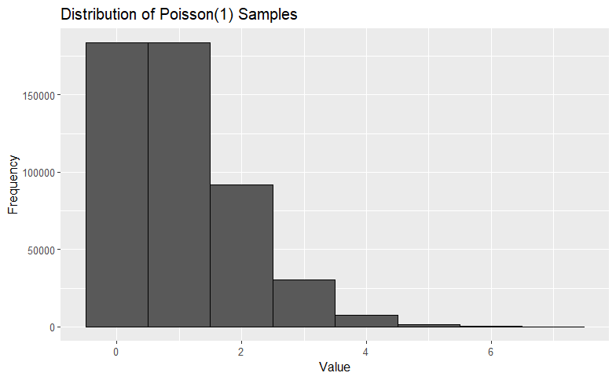

```r
Nvalues <- rpois(n = n_items * (n_items - 1) / 2, lambda = 1)
poisdis <- data.frame(Nvalues = Nvalues)

ggplot(poisdis, aes(x = Nvalues)) +
  geom_histogram(binwidth = 1, color = "black") +
  labs(title = "Distribution of Poisson(1) Samples",
       x = "Value", y = "Frequency")
```

### logic function for later use

```r
notzero <- Nvalues > 0
```

### build a empty matrix

```r
Nmatrix_empty <- Matrix(nrow = n_items, ncol = n_items)
```

### Identify the element which is not 0, later we want to fill into the matrix

```r
ij <- which(lower.tri(Nmatrix_empty), arr.ind = TRUE)[notzero, ]
```

### fill in the matrix with the generated data

```r
Nmatrix <- sparseMatrix(
  i = ij[, 1],
  j = ij[, 2],
  x = Nvalues[notzero],
  symmetric = TRUE,
  dims = c(n_items, n_items)
)
```

### generating “hidden ability value” for each player, assuming it is normally distributed

### and we divide by 4 to reduce the sd of generated data

```r
pi_vec <- exp(rnorm(n_items) / 4)
```

### now we normalize pi_vec so its mean is 1,eliminate parameter redundancy caused by the Bradley-Terry model’s scale invariance

```r
pi_vec <- pi_vec / mean(pi_vec)
```

### juz like the small data set, we do a simulation

### given the “hidden ability value” and “the number of time they played to each other”

```r
big_matrix <- simulate_BT(pi_vec, Nmatrix, nsim = 1, seed = 1)[[1]]
```

### convert the resulting matrix into a btdata object(the form this package can deal with)

```r
big_btdata <- btdata(big_matrix)
```

### check if it is fully connected

```r
summary(big_btdata)
```

```
Number of items: 1000
Density of wins matrix: 0.390967
Fully-connected: TRUE
```

### fit the model using MLE (a=1)

```r
the_model <- btfit(big_btdata, a = 1)
```

### extract the fitted ability parameters (pi)

```r
pi_fitted <- the_model$pi$full_dataset
```

### plot

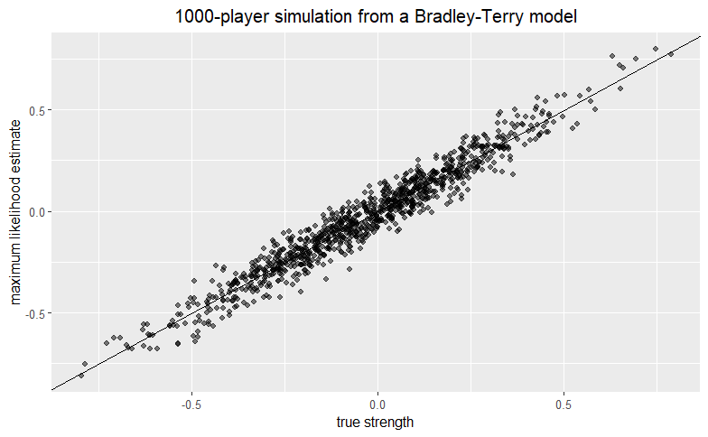

```r
plot_df <- tibble(
  x = log(pi_vec[as.numeric(names(pi_fitted))]),
  y = log(pi_fitted)
)

ggplot(plot_df, aes(x, y)) +
  geom_point(alpha = 0.5) +
  geom_abline() +
  xlab("true strength") +
  ylab("maximum likelihood estimate") +
  ggtitle("1000-player simulation from a Bradley-Terry model") +
  theme(plot.title = element_text(hjust = 0.5))
```